# Creating a plot of SST along a transect line

The goal is to make a plot of SST along transect lines. The motivation behind this is to show the spatio-temporal pattern of the SST fronts off the coast of Kochi.

## Set up the transects

Four transect lines are set up.

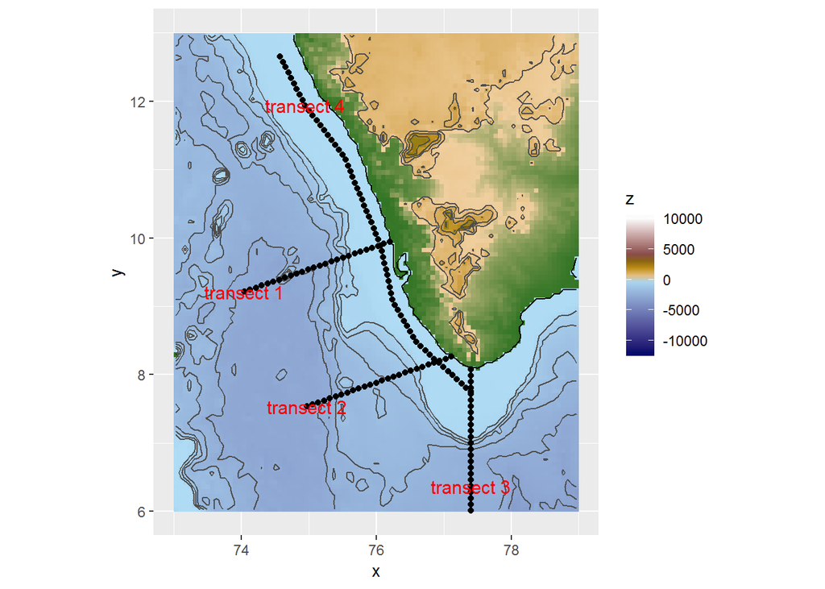

## Create SST plots for the whole year: Transect 1

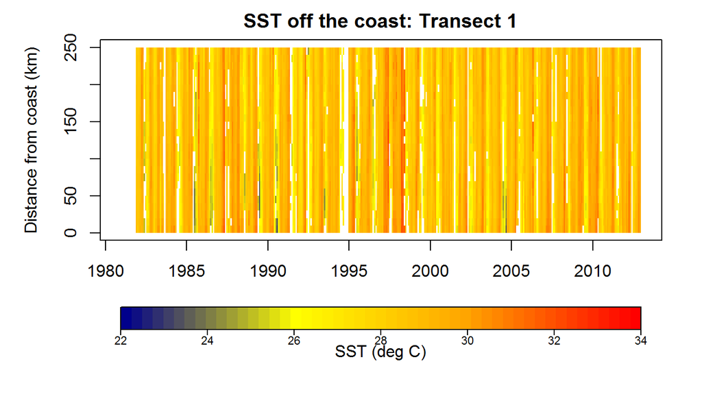

## Create colorbars for the whole year: Transect 2

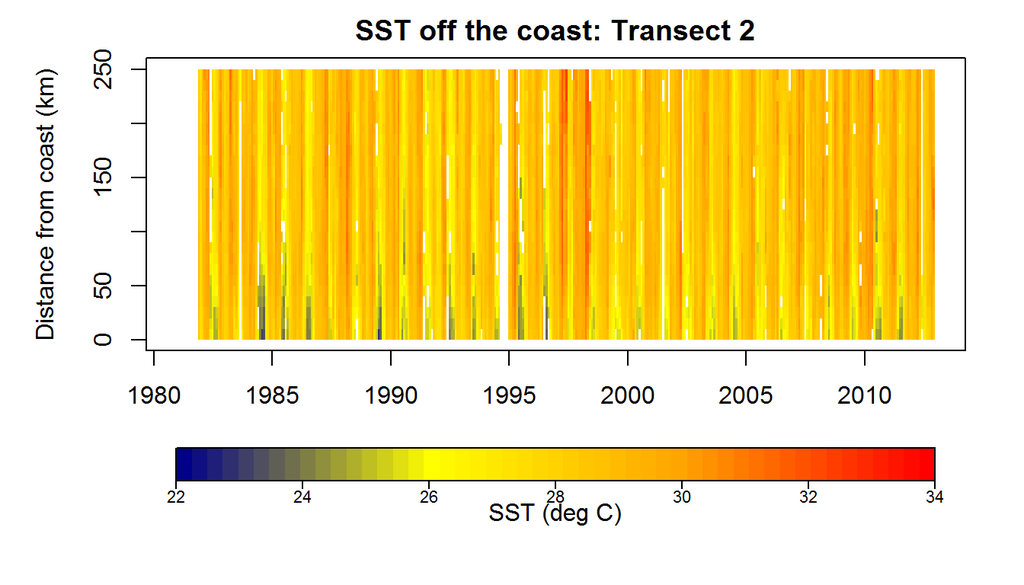

### Colormap for summer monsoon: Transect 2

Here I show the temperatures for just the summer months. You see colder tempeatures near the coast in the early years.

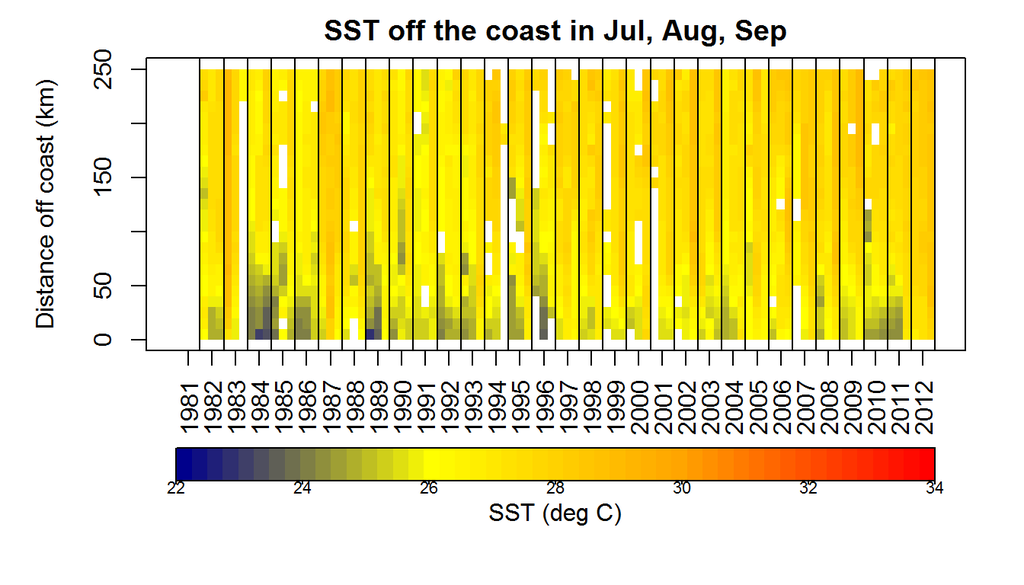

In some months, such as Aug 2011, there was a strong temperature gradient. While in other summer months, there is no gradient.

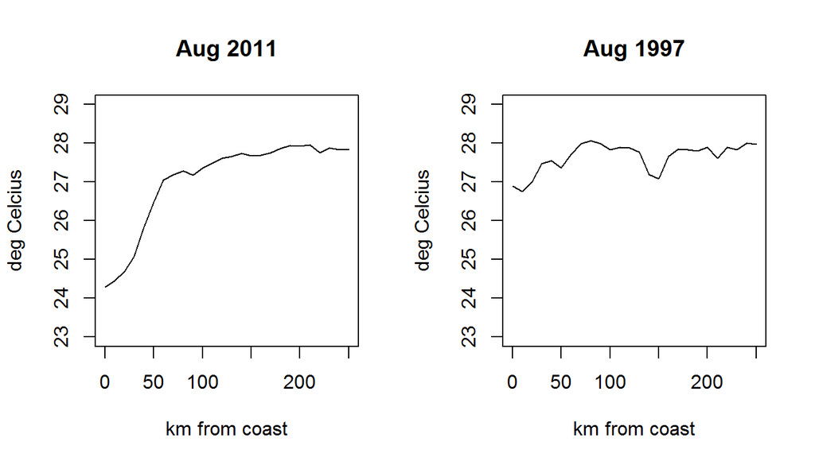

## Create colorbars for the whole year: Transect 3

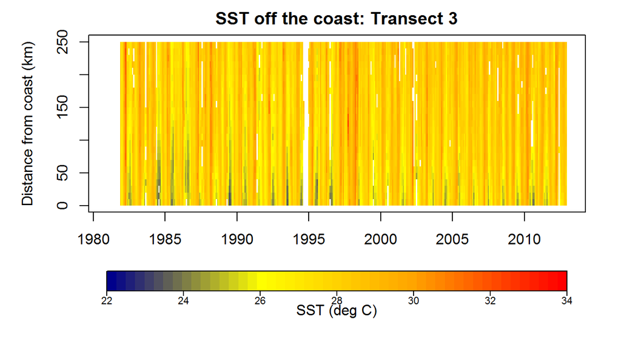

### Colormap for summer monsoon: Transect 3

In the far south (transect 3), you can see that the cold SST extended much farther offshore in the early years and more recently has been confined closer to the coast.

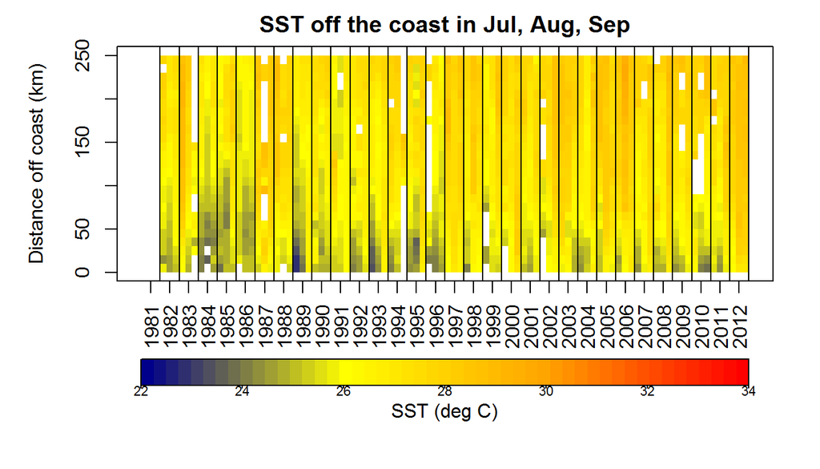

## Create colorbars for the whole year: Transect 4

This is a plot of the SST along the coast from the tip of India to the top of Kerala.

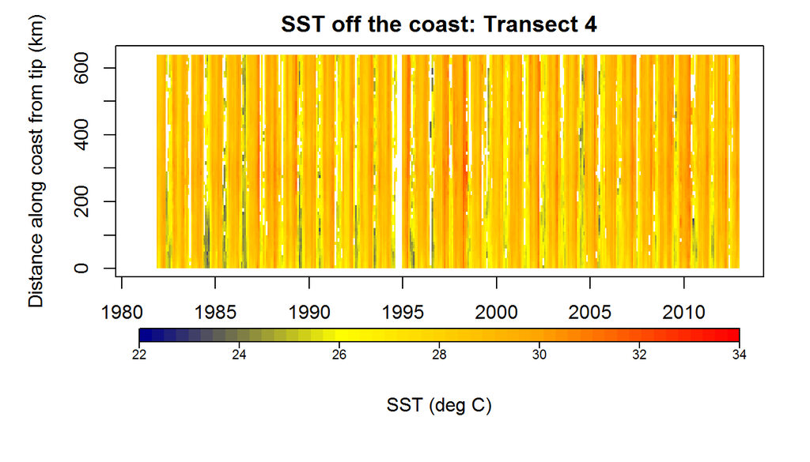

### Colormap for summer monsoon: Transect 4

In most summers, the cold water only extends 200 km from the tip of India.

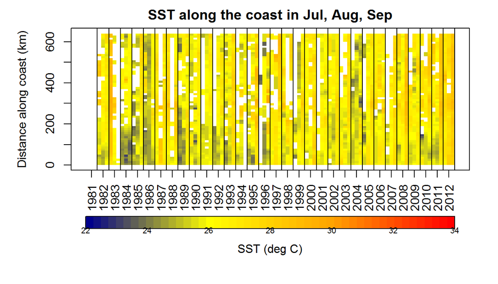

## Temperatures along the coast

In the first 3 months (Jan-Mar), the coast is uniformly warm with little variability between years.

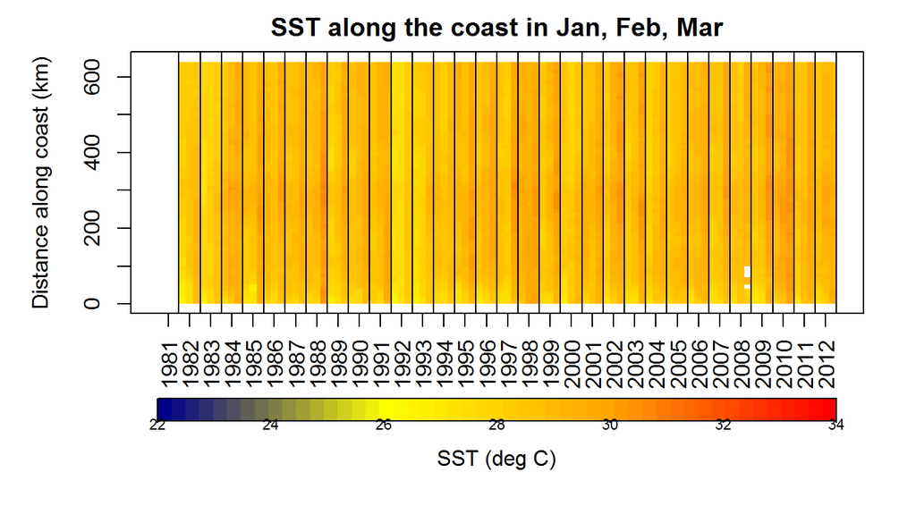

The mean temperature has been 29 deg Celcius with some years colder and others warmer. Temperatures have been generally increasing.

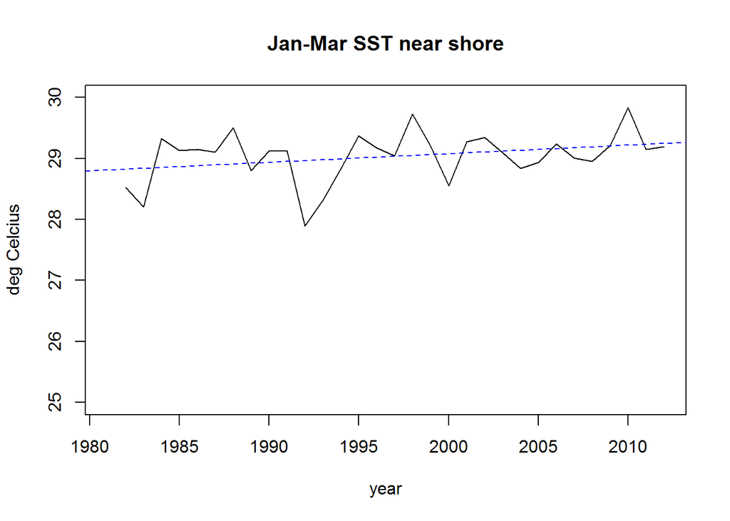

In the next 3 months (Apr-May), the coast is warmer and then makes a sudden shift to cooler temperatures.

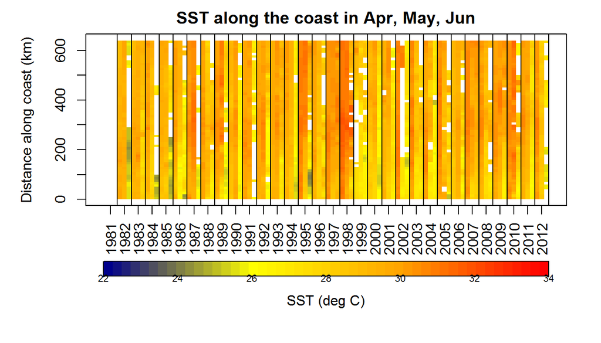

Here are the mean monthly nearshore temperatures. You can see the sudden cooling in June.

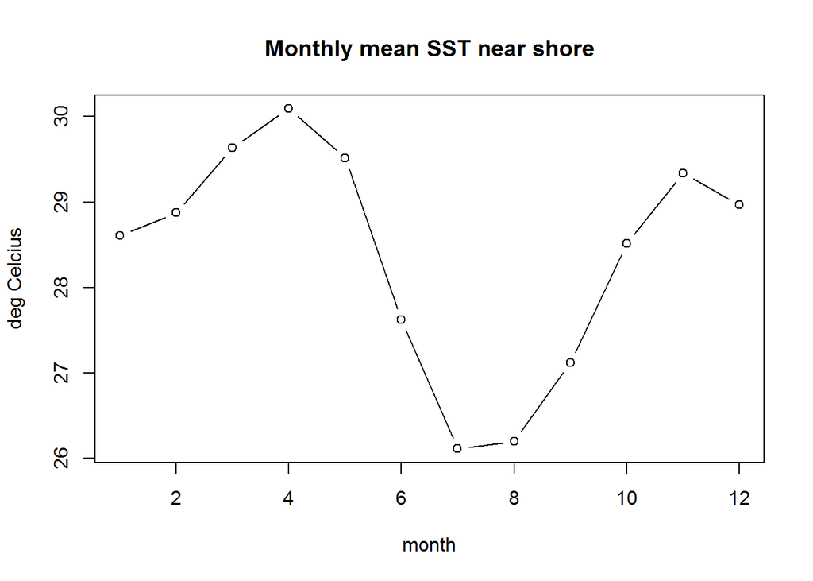

After the summer monsoon, (Oct-Nov), the coast is uniformly warm again with little variability between years.

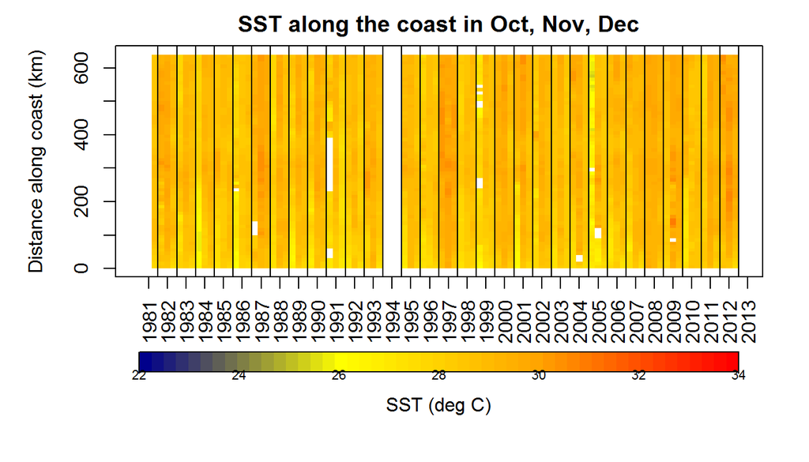

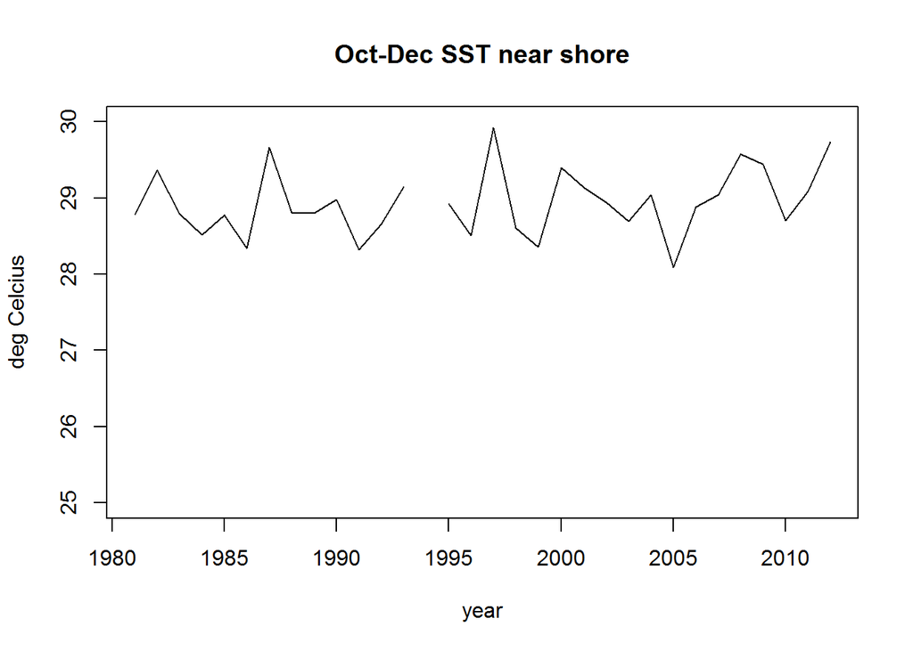

The summer monsoon, (Jul-Sep), is the period with great year to year variability in the near shore temperature and extent (up the coast) of the cold water.

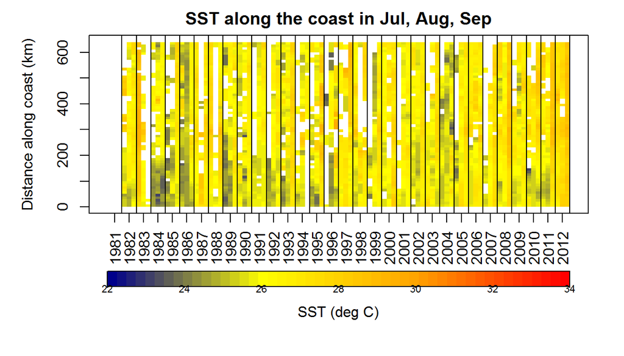

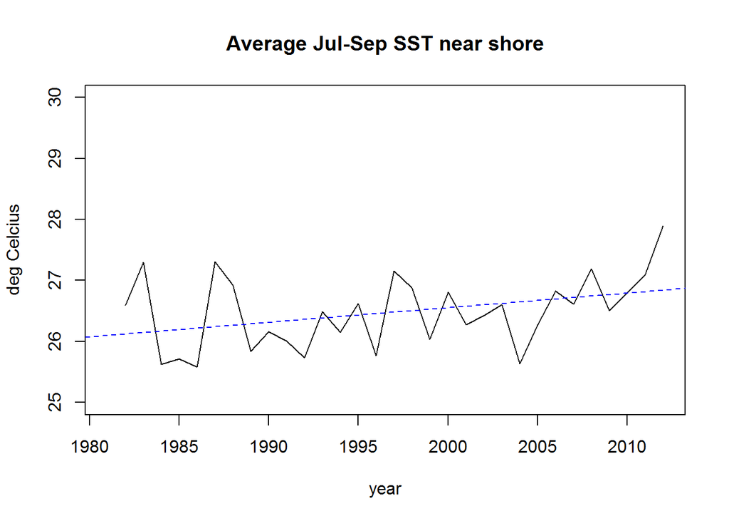